# Feature selection using MOFA

### clean environment

```r
rm(list=ls())
```

### set directory

```r
    knitr::opts_knit$set(root.dir = normalizePath("~/Desktop/Code-PHD/3_layers_integration/"))
```

```r
library(xlsx)
library(dplyr)
library(circlize)
library(MOFA2)
library(compositions)
```

```r
conv_met <- read.csv("/home/flomik/Desktop/Code-PHD/3_layers_integration/processing/biochemical_super_path.csv")
names(conv_met)[1] <- "met"
conv_lip <- read.csv("/home/flomik/Desktop/Code-PHD/3_layers_integration/processing/lipids_superpathways.csv")
names(conv_lip)[1] <- "item"
tax_table <- read.csv("/home/flomik/Desktop/Code-PHD/3_layers_integration/processing/tax_table_COCOMO.csv")
tax_table <- select(tax_table, X, Division, Family, Genus)
names(tax_table)[1] <- "item"
```

# Background

## Factors

MOFA factors capture the global sources of variability in the data. Mathematically, each factor ordinates cells along a one-dimensional axis centered at zero. The value per se is not interpretable, only the relative positioning of samples is important. Samples with different signs manifest opposite “effects” along the inferred axis of variation, with higher absolute value indicating a stronger effect. Note that the interpretation of factors is analogous to the interpretation of the principal components in PCA.

## Weights

Weights provide a score for how strong each feature relates to each factor, hence allowing a biological interpretation of the latent factors. Features with no as- sociation with the factor have values close to zero, while genes with strong association with the factor have large absolute values. The sign of the weight indicates the direction of the effect: a positive weight indicates that the feature has higher levels in the cells with positive factor values, and vice versa

## Use of covariates

We extensively tested this functionality and it was not yielding good results. The reason is that covariates are usually discrete labels that do not reflect the underlying molecular biology. For example, if you introduce age as a covariate, but the actual age is different from the molecular age, the model will simply learn a new factor that corresponds to this latent molecular age, and it will drop the covariate from the model. We recommend that you learn the factors in a completely unsupervised manner and then relate them to the biological covariates a posteriori (see vignettes). If your covariate of interest is an important driver of variability, do not worry, MOFA will find it!

# Analysis

```r
name_ana <- "microbiome_project"
```

```r
library(xlsx)
library(dplyr)
library(SNFtool)
library(ROCR)
library(cvAUC)
library(circlize)
library(MOFA2)
library("rhdf5")
library(ComplexHeatmap)
library(ggplot2)
```

```r
col <- c("#6b8150", "#2273C3","#EFC144","#868686")
#col_border <- darken(col, 0.5)
```

```r
cluster <- read.csv("processing/cluster_SNF_3_omics_3_clusters_plusHC.csv")
cluster <- cluster[!is.na(cluster$cluster),]
cluster$X <- NULL
names(cluster)[2] <- "X"
```

## load clinical

```r
clinical <- read.csv("/home/flomik/Desktop/Code-PHD/3_layers_integration/processing/clinical_data_microbiome_project.csv")
clinical$Combined_therapy <- gsub("\\/.*", "", clinical$Combined_therapy)
clinical$Combined_therapy <- ifelse(clinical$Combined_therapy %in% c("ABC", "AZT", "TAF", "TDF"), clinical$Combined_therapy, "Others")
clinical_data <- merge(cluster, clinical, by = "X")
clinical_data$CD4_CD8 <- NA
clinical_data$CD4_CD8 <- clinical_data$CD4/clinical_data$CD8
clinical_data <- select(clinical_data, X, cluster, hypertension, Transm_mode, VAT, SAT, CD4_CD8, METS, AGE, BMI, Combined_therapy, X3rd_Drug, GENDER)
names(clinical_data)[1] <- "sample"
clinical_data$group <- "group1"
clinical_data$cluster <- paste0("C", clinical_data$cluster)
```

## Load data

```r
data_lip <- read.csv("data/clp_lipidomics_data.csv")
data_met <- read.csv("data/cocomo_norm_data_filt.csv")
data_met <- data_met[data_met$SUPER.PATHWAY !="",]
```

## lipidome

```r
data_lip <- data_lip[data_lip$SUPER_PATHWAY !="",]
data_lip <- data_lip[,c(1, 9:228)]
names(data_lip) <- gsub("X", "", names(data_lip))
lip <- data_lip$BIOCHEMICAL
data_lip <- data.frame(t(data_lip[,-1]))
colnames(data_lip) <- lip
grep("Total", colnames(data_lip))
```

```
 [1] 964 965 966 967 968 969 970 971 972 973 974 975 976 977
```

```r
data_lip <- data_lip[rownames(data_lip) %in% clinical_data$sample, ]
data_lip <- data_lip[,1:963]
grep("Total", colnames(data_lip))
```

```
integer(0)
```

```r
data_lip <- log2(data_lip)
#data_lip <- data.frame(t(scale(t(data_lip), scale = TRUE)))
#data_lip <- data_lip[, sapply(data_lip, var) > 0.05]
```

## metabolome

```r
data_met <- data_met[,c(1,13:232)]
names(data_met)[-1] <- gsub("X", "", names(data_met)[-1])
met <- data_met$BIOCHEMICAL
data_met <- data.frame(t(data_met[,-1]))
colnames(data_met) <- met
data_met <- data_met[rownames(data_met) %in% clinical_data$sample, ]
data_met <- log2(data_met)
#data_met <- data.frame(t(scale(t(data_met), scale = TRUE)))
#data_met <- data_met[, sapply(data_met, var) > 0.05]
data_met <- data_met[order(match(rownames(data_met), rownames(data_lip))), ]
```

## microbiome

```r
data_mi <- read.csv("/home/flomik/Desktop/Code-PHD/3_layers_integration/processing/data_count_microbiome.csv")
rownames(data_mi) <- data_mi$X
data_mi$X <- NULL
rownames(data_mi) <- gsub("X","",rownames(data_mi))
data_mi <- data_mi[rownames(data_mi) %in% rownames(data_lip), ]
data_mi <- data.frame(clr(data_mi))
#data_mi <- data.frame(t(scale(t(data_mi), scale = FALSE)))
data_mi <- data_mi[, sapply(data_mi, var) > 0.2]
data_mi <- data_mi[order(match(rownames(data_mi), rownames(data_lip))), ]
```

```r
convert_met <- data.frame(met = colnames(data_met), nb = paste0("Met", 1:ncol(data_met)))
colnames(data_met) <- convert_met$nb
```

## load model (made using defaults parameters)

```r
MOFAobject <- load_model("/home/flomik/Desktop/Code-PHD/3_layers_integration/results/mofa_model_4")
```

## add metadata

```r
# Sanity check
stopifnot(all(sort(clinical_data$sample)==sort(unlist(samples_names(MOFAobject)))))

# Add sample metadata to the model
samples_metadata(MOFAobject) <- clinical_data
```

## Model overview.

```r
plot_data_overview(MOFAobject)
pdf("results/figures_2/MOFA_overview_model_4.pdf")
```

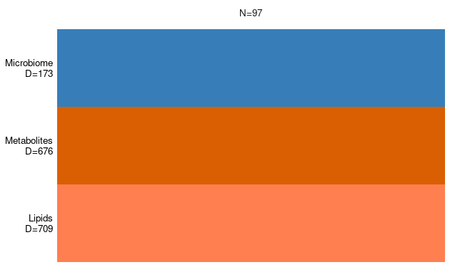

```r
plot_data_overview(MOFAobject)
dev.off()
```

==> no missing values –> correct numbers of feactures and samples

## correlation factors

Verify that the Factors are largely uncorrelated

```r
plot_factor_cor(MOFAobject)
pdf("results/figures_2/correlation_factors_model_4.pdf")
```

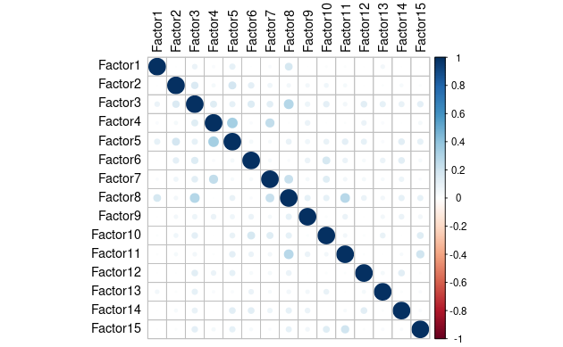

```r
plot_factor_cor(MOFAobject)
dev.off()
```

## variance decomposition by factor

```r
plot_variance_explained(MOFAobject)
pdf("results/figures_2/MOFA_variance_model_4.pdf")
```

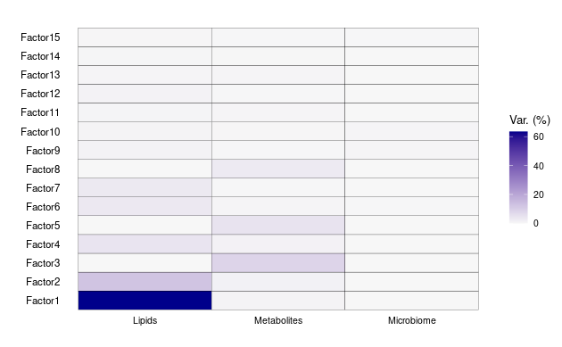

```r
plot_variance_explained(MOFAobject)
dev.off()
```

## Total variance

```r
plot_variance_explained(MOFAobject, plot_total = T)[[2]]
pdf("results/figures_2/MOFA_variance_modeL_4_2.pdf")
```

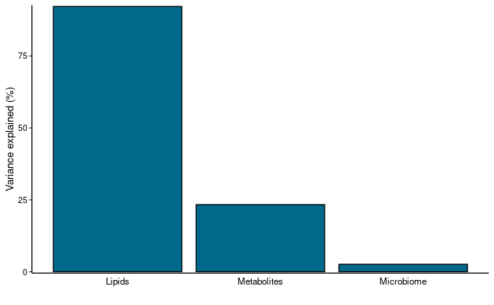

```r
plot_variance_explained(MOFAobject, plot_total = T)[[2]]
dev.off()
```

## checking model / percentage variance per factor

```r
MOFAobject@cache
```

```
$variance_explained
$variance_explained$r2_total
$variance_explained$r2_total$group1
     Lipids Metabolites  Microbiome
   92.22305    23.33402     2.59864


$variance_explained$r2_per_factor
$variance_explained$r2_per_factor$group1
               Lipids Metabolites Microbiome
Factor1  6.345221e+01   0.9469549 0.03792730
Factor2  1.244164e+01   1.4594240 0.04150398
Factor3  7.455830e-04   8.4866669 0.03837044
Factor4  4.517835e+00   1.3405908 0.03436910
Factor5  1.631266e-03   4.8802133 0.01998709
Factor6  3.510264e+00   0.7320754 0.21874980
Factor7  3.459887e+00   0.2308606 0.09703587
Factor8  8.712988e-04   3.1376780 0.09087425
Factor9  1.267677e+00   0.2960543 0.74350190
Factor10 9.477534e-01   0.4368742 0.74766378
Factor11 8.170180e-01   0.7460653 0.06829336
Factor12 1.308681e+00   0.1879514 0.04577402
Factor13 6.523773e-01   0.6630640 0.06480556
Factor14 5.908520e-01   0.3400394 0.05332654
Factor15 4.802606e-01   0.1834671 0.30540226
```

## Association factors / clinical parameters

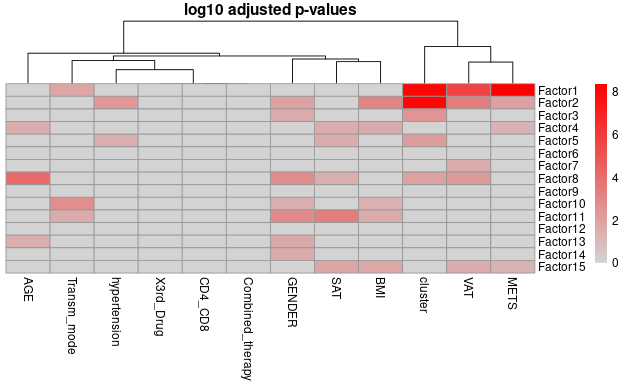

```r
correlate_factors_with_covariates(MOFAobject,
  covariates = c("cluster", "hypertension", "Transm_mode", "VAT", "SAT","CD4_CD8", "METS", "AGE", "BMI", "Combined_therapy", "GENDER", "X3rd_Drug"),
  plot="log_pval"
)
pdf("results/figures_2/MOFA_covariate_association_model_4.pdf")
```

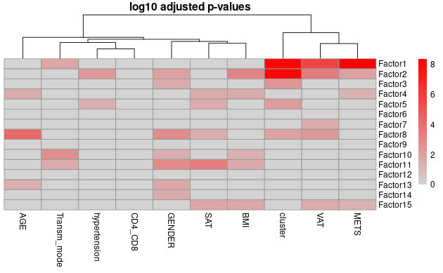

```r
correlate_factors_with_covariates(MOFAobject,
  covariates = c("cluster", "hypertension", "Transm_mode", "VAT", "SAT","CD4_CD8", "METS", "AGE", "BMI", "GENDER"),
  plot="log_pval"
)
dev.off()
```

## relationship clinical data and latent factors

```r
factors <- data.frame(sample = rownames(MOFAobject@expectations$Z$group1), MOFAobject@expectations$Z$group1)
factors_clinical <- merge(clinical_data, factors, by = "sample")
total_regression_table <- as.data.frame(matrix(0,nrow=0,ncol=7))
colnames(total_regression_table) <- c("Clinical_parameter","Factor","Estimate","StdError","tStat","pvalue", "padjust")

for (i in 2:13) {
  for(j in 15:29){
    plm <- as.data.frame(matrix(0,nrow=1,ncol=6))
    colnames(plm) <- c("Clinical_parameter","Factor","Estimate","StdError","tStat","pvalue")
    plm[1, 1] <- names(factors_clinical)[j]
    plm[1, 2] <- names(factors_clinical)[i]
    plm[1,3:6] <- coef(summary(lm(factors_clinical[,j] ~ factors_clinical[,i], data = factors_clinical)))[2,]
    plm$padjust <- p.adjust(plm$pvalue,method="BH")
    total_regression_table <- rbind(total_regression_table, plm)
  }
}

sigplm <- total_regression_table[total_regression_table$padjust<0.1,] #look only at those with adjusted p.value < 0.05


write.csv(sigplm, "processing/association_clinical_MOFA_latent_factors.csv")
```

### plot weight distribution

```r
pdf("results/figures_2/weight_distribution_factors.pdf")
ggplot(data.frame(MOFAobject@expectations$W$Lipids), aes(x=Factor1)) +
    geom_histogram(aes(y=..density..),      # Histogram with density instead of count on y-axis
                   binwidth=.01,
                   colour="black", fill="white") +
    geom_density(alpha=.2, fill="#FF6666")+ggtitle("Lipids Factor 1 weights distribution")

ggplot(data.frame(MOFAobject@expectations$W$Lipids), aes(x=Factor2)) +
    geom_histogram(aes(y=..density..),      # Histogram with density instead of count on y-axis
                   binwidth=.01,
                   colour="black", fill="white") +
    geom_density(alpha=.2, fill="#FF6666")+ggtitle("Lipids Factor 2 weights distribution")
```

```r
ggplot(data.frame(MOFAobject@expectations$W$Metabolites), aes(x=Factor3)) +
    geom_histogram(aes(y=..density..),      # Histogram with density instead of count on y-axis
                   binwidth=.01,
                   colour="black", fill="white") +
    geom_density(alpha=.2, fill="#FF6666")+ggtitle("Metabolites Factor 1 weights distribution")

ggplot(data.frame(MOFAobject@expectations$W$Metabolites), aes(x=Factor1)) +
    geom_histogram(aes(y=..density..),      # Histogram with density instead of count on y-axis
                   binwidth=.01,
                   colour="black", fill="white") +
    geom_density(alpha=.2, fill="#FF6666")+ggtitle("Metabolites Factor 1 weights distribution")
```

```r
ggplot(data.frame(MOFAobject@expectations$W$Metabolites), aes(x=Factor2)) +
    geom_histogram(aes(y=..density..),      # Histogram with density instead of count on y-axis
                   binwidth=.01,
                   colour="black", fill="white") +
    geom_density(alpha=.2, fill="#FF6666")+ggtitle("Metabolites Factor 2 weights distribution")

ggplot(data.frame(MOFAobject@expectations$W$Metabolites), aes(x=Factor3)) +
    geom_histogram(aes(y=..density..),      # Histogram with density instead of count on y-axis
                   binwidth=.01,
                   colour="black", fill="white") +
    geom_density(alpha=.2, fill="#FF6666")+ggtitle("Metabolites Factor 2 weights distribution")
```

```r
ggplot(data.frame(MOFAobject@expectations$W$Microbiome), aes(x=Factor1)) +
    geom_histogram(aes(y=..density..),      # Histogram with density instead of count on y-axis
                   binwidth=.001,
                   colour="black", fill="white") +
    geom_density(alpha=.2, fill="#FF6666")+ggtitle("Microbiome Factor 1 weights distribution")

ggplot(data.frame(MOFAobject@expectations$W$Microbiome), aes(x=Factor2)) +
    geom_histogram(aes(y=..density..),      # Histogram with density instead of count on y-axis
                   binwidth=.001,
                   colour="black", fill="white") +
    geom_density(alpha=.2, fill="#FF6666")+ggtitle("Microbiome Factor 2 weights distribution")
```

```r
ggplot(data.frame(MOFAobject@expectations$W$Microbiome), aes(x=Factor3)) +
    geom_histogram(aes(y=..density..),      # Histogram with density instead of count on y-axis
                   binwidth=.001,
                   colour="black", fill="white") +
    geom_density(alpha=.2, fill="#FF6666")+ggtitle("Microbiome Factor 2 weights distribution")

dev.off()
```

## checking weigths features

lip_f1 <- MOFAobject@expectations$W$Lipids[abs(MOFAobject@expectations$W$Lipids[,1]) > 0.08,] met_f1 <- MOFAobject@expectations$W$Metabolites[abs(MOFAobject@expectations$W$Metabolites[,1]) > 0.08,] mic_f1 <- MOFAobject@expectations$W$Microbiome[abs(MOFAobject@expectations$W$Microbiome[,1]) > 0.08,]

lip_f2 <- MOFAobject@expectations$W$Lipids[abs(MOFAobject@expectations$W$Lipids[,2]) > 0.08,] met_f2 <- MOFAobject@expectations$W$Metabolites[abs(MOFAobject@expectations$W$Metabolites[,2]) > 0.08,] mic_f2 <- MOFAobject@expectations$W$Microbiome[abs(MOFAobject@expectations$W$Microbiome[,2]) > 0.08,]

lip_f5 <- MOFAobject@expectations$W$Lipids[abs(MOFAobject@expectations$W$Lipids[,5]) > 0.08,] met_f5 <- MOFAobject@expectations$W$Metabolites[abs(MOFAobject@expectations$W$Metabolites[,5]) > 0.08,] mic_f5 <- MOFAobject@expectations$W$Microbiome[abs(MOFAobject@expectations$W$Microbiome[,5]) > 0.08,]

## extract all features

```r
list_lip <- MOFAobject@expectations$W$Lipids
list_met <- MOFAobject@expectations$W$Metabolites
list_mic <- MOFAobject@expectations$W$Microbiome
```

## extract upper and lower quantiles

```r
lip_f1 <- MOFAobject@expectations$W$Lipids[MOFAobject@expectations$W$Lipids[,1] > quantile(MOFAobject@expectations$W$Lipids[,1], .95) |
  MOFAobject@expectations$W$Lipids[,1] < quantile(MOFAobject@expectations$W$Lipids[,1], .05), ]
met_f1 <- MOFAobject@expectations$W$Metabolites[MOFAobject@expectations$W$Metabolites[,1] > quantile(MOFAobject@expectations$W$Metabolites[,1], .95) |
  MOFAobject@expectations$W$Metabolites[,1] < quantile(MOFAobject@expectations$W$Metabolites[,1], .05),]
mic_f1 <- MOFAobject@expectations$W$Microbiome[MOFAobject@expectations$W$Microbiome[,1] > quantile(MOFAobject@expectations$W$Microbiome[,1], .95) |
  MOFAobject@expectations$W$Microbiome[,1] < quantile(MOFAobject@expectations$W$Microbiome[,1], .25),]


lip_f2 <- MOFAobject@expectations$W$Lipids[MOFAobject@expectations$W$Lipids[,2] > quantile(MOFAobject@expectations$W$Lipids[,2], .95) |
  MOFAobject@expectations$W$Lipids[,2] < quantile(MOFAobject@expectations$W$Lipids[,2], .05), ]
met_f2 <- MOFAobject@expectations$W$Metabolites[MOFAobject@expectations$W$Metabolites[,2] > quantile(MOFAobject@expectations$W$Metabolites[,2], .95) |
  MOFAobject@expectations$W$Metabolites[,2] < quantile(MOFAobject@expectations$W$Metabolites[,2], .05),]
mic_f2 <- MOFAobject@expectations$W$Microbiome[MOFAobject@expectations$W$Microbiome[,2] > quantile(MOFAobject@expectations$W$Microbiome[,2], .95) |
  MOFAobject@expectations$W$Microbiome[,2] < quantile(MOFAobject@expectations$W$Microbiome[,2], .05),]


lip_f3 <- MOFAobject@expectations$W$Lipids[MOFAobject@expectations$W$Lipids[,3] > quantile(MOFAobject@expectations$W$Lipids[,3], .95) |
  MOFAobject@expectations$W$Lipids[,3] < quantile(MOFAobject@expectations$W$Lipids[,3], .05), ]
met_f3 <- MOFAobject@expectations$W$Metabolites[MOFAobject@expectations$W$Metabolites[,3] > quantile(MOFAobject@expectations$W$Metabolites[,3], .95) |
  MOFAobject@expectations$W$Metabolites[,3] < quantile(MOFAobject@expectations$W$Metabolites[,3], .05),]
mic_f3 <- MOFAobject@expectations$W$Microbiome[MOFAobject@expectations$W$Microbiome[,3] > quantile(MOFAobject@expectations$W$Microbiome[,3], .95) |
  MOFAobject@expectations$W$Microbiome[,3] < quantile(MOFAobject@expectations$W$Microbiome[,3], .05),]


lip_f5 <- MOFAobject@expectations$W$Lipids[MOFAobject@expectations$W$Lipids[,5] > quantile(MOFAobject@expectations$W$Lipids[,5], .95) |
  MOFAobject@expectations$W$Lipids[,5] < quantile(MOFAobject@expectations$W$Lipids[,5], .05), ]
met_f5 <- MOFAobject@expectations$W$Metabolites[MOFAobject@expectations$W$Metabolites[,5] > quantile(MOFAobject@expectations$W$Metabolites[,5], .95) |
  MOFAobject@expectations$W$Metabolites[,5] < quantile(MOFAobject@expectations$W$Metabolites[,5], .05),]
mic_f5 <- MOFAobject@expectations$W$Microbiome[MOFAobject@expectations$W$Microbiome[,5] > quantile(MOFAobject@expectations$W$Microbiome[,5], .95) |
  MOFAobject@expectations$W$Microbiome[,5] < quantile(MOFAobject@expectations$W$Microbiome[,5], .05),]

lip_f8 <- MOFAobject@expectations$W$Lipids[MOFAobject@expectations$W$Lipids[,8] > quantile(MOFAobject@expectations$W$Lipids[,8], .95) |
  MOFAobject@expectations$W$Lipids[,8] < quantile(MOFAobject@expectations$W$Lipids[,8], .05), ]
met_f8 <- MOFAobject@expectations$W$Metabolites[MOFAobject@expectations$W$Metabolites[,8] > quantile(MOFAobject@expectations$W$Metabolites[,8], .95) |
  MOFAobject@expectations$W$Metabolites[,8] < quantile(MOFAobject@expectations$W$Metabolites[,8], .05),]
mic_f8 <- MOFAobject@expectations$W$Microbiome[MOFAobject@expectations$W$Microbiome[,8] > quantile(MOFAobject@expectations$W$Microbiome[,8], .95) |
  MOFAobject@expectations$W$Microbiome[,8] < quantile(MOFAobject@expectations$W$Microbiome[,8], .05),]
```

## heatmap with everything

```r
col_fun1 = colorRamp2(c(-6,-2,-1, 0,1,2,6), c("#7F7F00","#B2B200" ,"#E5E500","white","#BF7FBF","#993299","#590059"))
```

```r
library(reshape2)
lip <- data.frame(MOFAobject@expectations$W$Lipids)
lip <- select(lip, Factor1, Factor2, Factor3, Factor5, Factor8)
lip$Item <- rownames(lip)
lip <- melt(lip, id.vars = c("Item"))
lip_3 <- lip
lip$value <- abs(lip$value)
lip <- lip[order(lip$value, decreasing = TRUE),]
lip <- lip[1:20,]
lip_2 <- lip_3[lip_3$Item %in% lip$Item & lip_3$variable %in% lip$variable,]

lip <- data.frame(MOFAobject@expectations$W$Metabolites)
lip <- select(lip, Factor1, Factor2, Factor3, Factor5, Factor8)
lip$Item <- rownames(lip)
lip <- melt(lip, id.vars = c("Item"))
lip_3 <- lip
lip$value <- abs(lip$value)
lip <- lip[order(lip$value, decreasing = TRUE),]
lip <- lip[1:20,]
met_2 <- lip_3[lip_3$Item %in% lip$Item & lip_3$variable %in% lip$variable,]

lip <- data.frame(MOFAobject@expectations$W$Microbiome)
lip <- select(lip, Factor1, Factor2, Factor3, Factor5, Factor8)
lip$Item <- rownames(lip)
lip <- melt(lip, id.vars = c("Item"))
lip_3 <- lip
lip$value <- abs(lip$value)
lip <- lip[order(lip$value, decreasing = TRUE),]
lip <- lip[1:20,]
mic_2 <- lip_3[lip_3$Item %in% lip$Item & lip_3$variable %in% lip$variable,]
```

```r
selection_items <- c(rownames(lip_f1), rownames(met_f1), rownames(mic_f1),
                                      rownames(lip_f2), rownames(met_f2), rownames(mic_f2),
                                      rownames(lip_f3), rownames(met_f3), rownames(mic_f3),
                                      rownames(lip_f5), rownames(met_f5), rownames(mic_f5),
                                      rownames(lip_f8), rownames(met_f8), rownames(mic_f8)
                                      )

table_items <- data.frame(item = unique(selection_items))
table_items$type <- "Lip"
table_items$type <-  ifelse(grepl("Met", table_items$item), "Met", table_items$type)
table_items$type <-  ifelse(grepl("Otu", table_items$item), "Otu", table_items$type)

names(convert_met)[2] <- "item"
table_items <- merge(table_items, convert_met, all.x = TRUE, by = "item")
table_items <- merge(table_items, conv_lip, all.x = TRUE, by = "item")
table_items <- merge(table_items, tax_table, all.x = TRUE, by = "item")
table_items <- merge(table_items, conv_met, all.x = TRUE, by = "met")
table_items$names <- NA

table_items$names[table_items$item %in% lip_2$Item] <- table_items$item[table_items$item %in% lip_2$Item]
table_items$names[table_items$item %in% met_2$Item] <- table_items$met[table_items$item %in% met_2$Item]
table_items$names[table_items$item %in% mic_2$Item] <- table_items$Genus[table_items$item %in% mic_2$Item]
```

```r
imp <- rbind(lip_2, met_2, mic_2)
names(convert_met)[2] <- "Item"
imp <- merge(imp, convert_met, by = "Item", all.x = TRUE)
names(tax_table)[1] <- "Item"
imp <- merge(imp, tax_table, all.x = TRUE, by = "Item")
imp$type <- NA
imp$type[grepl("Met", imp$Item)] <- "met"
imp$type[grepl("Otu", imp$Item)] <- "otu"
imp$type[is.na(imp$type)] <- "lip"
imp$Item[grepl("Met", imp$Item)] <- imp$met[grepl("Met", imp$Item)]

imp$Item[grepl("Otu", imp$Item)] <- imp$Division[grepl("Otu", imp$Item)]
```

## bubble plot

```r
imp <- imp[!imp$Item %in% c("uncultured", "."),]
imp <- imp[order(abs(imp$value), decreasing = TRUE),]
imp <- distinct(imp, Item, variable, .keep_all= TRUE)
```

```r
dge <- read.delim("processing/processing_microbione_derived_metabolomics_filt.csv", sep = ",")
m <- imp$met[which(imp$met %in% dge$Metabolite == TRUE)]
```

```r
bold.labels
```

```
 [1] "plain" "plain" "plain" "plain" "plain" "plain" "plain" "plain" "plain" "plain" "plain" "plain" "plain" "plain" "plain" "plain" "plain" "plain" "plain" "plain" "plain" "plain" "plain" "plain"
[25] "plain" "plain" "plain" "plain" "bold"  "plain" "plain" "plain" "bold"  "plain" "plain" "plain" "plain" "bold"  "plain" "plain" "plain" "plain" "plain" "plain" "plain" "plain" "plain" "plain"
[49] "plain" "plain" "plain" "plain" "plain" "plain" "plain" "plain" "plain" "plain" "plain" "plain" "plain"
```

```r
m
```

```
[1] "3,4-dihydroxybutyrate" "2-oxindole-3-acetate"  "indoleacetylglutamine"
```

[figure not shown]

```r
ggplot(imp, aes(x = reorder(Item, abs(value)), y = abs(value))) +
  geom_segment(aes(x = reorder(Item, abs(value)),
                   xend = reorder(Item, abs(value)),
                   y = 0, yend = abs(value)),
               color = "gray", lwd = 1) +
  geom_point(size = 4, bg = 4, aes(x = reorder(Item, abs(value)), y = abs(value), col = variable, fill = variable, shape = type)) +
  xlab("Top items") +
  ylab("") +
  coord_flip() +
  theme_minimal()+scale_color_manual(values = c("#4c8577", "#774c85","#85774c", "#8e0000"))+
  theme(axis.text.y = element_text(face = bold.labels))
ggsave("results/figures/top_20_items_MOFA.pdf", width = 5.5, height = 7)
```

```r
imp_2 <- imp[reorder(imp$Item, abs(imp$value)), ]
```

```r
names(conv_met)[1] <- "Item"
names(conv_lip)[1] <- "Item"

imp_3 <- merge(imp_2, conv_met, by = "Item", all.x = TRUE)
imp_3 <- merge(imp_3, conv_lip, by = "Item", all.x = TRUE)
imp_3$group <- NA

imp_3$group[imp_3$type == "lip"] <- imp_3$SUPER_PATHWAY[imp_3$type == "lip"]
imp_3$group[imp_3$type == "met"] <- imp_3$SUPER.PATHWAY[imp_3$type == "met"]
imp_3$group[imp_3$type == "otu"] <- imp_3$Division[imp_3$type == "otu"]

imp_4 <- select(imp_3, Item, group)
```

```r
mycols_lip <- c("#34558b", "#f0daa4", "#eaac9d", "#798fa8", "#fd823e", "#117893", "#d13b40", "#ffaf12", "#a2553a")
```

```r
mycols_met <- c("#34558b", "#f0daa4", "#eaac9d", "#798fa8", "#fd823e", "#117893", "#d13b40", "#ffaf12", "#a2553a")
```

```r
color_phylym <- c("#8b0000","#eb8c00","#f9d62e","#c9df8a","#36802d","#77ab59","#71c7ec","#189ad3","#1ebbd7","#eec1ad","#ff7f50","#e0301e","#e5e5e5", "grey", "blue", "green", "pink")
```

```r
imp_4$value
```

[output not shown]

```r
pdf("results/figures/top_MOFA_20_annotation.pdf")
ha = HeatmapAnnotation(bar = as.factor(imp_4$group), col = list(bar = c("Lipid" = "red",
                                                                        "Amino Acid" = mycols_met[1],
                                                                        "Xenobiotics" = mycols_met[2],
                                                                        "Nucleotide" = mycols_met[3],
                                                                        "Carbohydrate" = mycols_met[4],
                                                                        "Cofactors and Vitamins" = mycols_met[5],

                                                                        "Bacteroidetes" = color_phylym[6],
                                                                        "Actinobacteria" = color_phylym[1],
                                                                        "Cyanobacteria" = color_phylym[2],
                                                                        "Firmicutes" = color_phylym[3],
                                                                        "Lentisphaerae" = color_phylym[4],
                                                                        "Proteobacteria" = color_phylym[5],

                                                                        "Triacylglycerol" = mycols_lip[1])))
draw(ha)
dev.off()
```

```r
pdf("results/figures_2/heatmap_F1_model_4.pdf")
ht = Heatmap(matrix(1:61, nrow = 61, ncol = 1), col = col_fun1, right_annotation = rowAnnotation(Class = as.factor(imp_4$group)))
draw(ht)
dev.off()
```

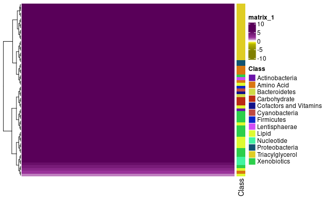

```r
draw(ht)
```

```r
phylum_colors <- c(
  "#CBD588", "#5F7FC7", "orange","#DA5724", "#508578", "#CD9BCD",
   "#AD6F3B", "#673770","#D14285", "#652926", "#C84248",
  "#8569D5", "#5E738F","#D1A33D", "#8A7C64", "#edf2ef")
```

```r
mycols_met <- c("#34558b", "#f0daa4", "#eaac9d", "#798fa8", "#fd823e", "#117893", "#d13b40", "#ffaf12", "#a2553a")
```

```r
pdf("results/figures_2/heatmap_all_factors_model_4_spearman_distance_2.pdf", width = 15, height = 15)
data <- cbind(data_met, data_lip, data_mi)
x <- colnames(data) %in% c(rownames(lip_f1), rownames(met_f1), rownames(mic_f1),
                                      rownames(lip_f2), rownames(met_f2), rownames(mic_f2),
                                      rownames(lip_f3), rownames(met_f3), rownames(mic_f3),
                                      rownames(lip_f5), rownames(met_f5), rownames(mic_f5),
                                      rownames(lip_f8), rownames(met_f8), rownames(mic_f8)
                                      )
y <- names(data)
y <- y[x]
data_2 <- data[,x]
names(data_2) <- y
data_2 <- data.frame(t(scale(t(data_2))))
data_2$X <- rownames(data_2)
data_2 <- merge(cluster, data_2, by = "X")
data_3 <- data.frame(t(data_2[,-c(1:2)]))
data_3$item <- y

data_4 <- merge(table_items, data_3, by = "item", all.y = TRUE)
data_4$type[is.na(data_4$type)] <- "lip"


table_items$SUPER_PATHWAY
```

[output not shown]

[output cut: 90 more lines]

```r
n <- c("Erysipelotrichaceae", "Lachnospiraceae", "Muribaculaceae", "Prevotellaceae", "Ruminococcaceae", "Veillonellaceae")

data_4$SUPER_PATHWAY[data_4$SUPER_PATHWAY %in% c("Cholesterol Ester", "Lysophosphatidylethanolamine", "MAG", "Phosphatidylinositol", "Sphingolipids", "Lysophosphatidylcholine")] <- "Other"
data_4$SUPER.PATHWAY[data_4$SUPER.PATHWAY %in% c("Partially Characterized Molecules", "Energy", "Cofactors and Vitamins", "Nucleotide")] <- "Other"
data_4$Family[!data_4$Family %in% n & !is.na(data_4$Family)] <- "Other"
table(data_4$Division)
```

```
    Actinobacteria      Bacteroidetes      Cyanobacteria Epsilonbacteraeota         Firmicutes      Lentisphaerae     Proteobacteria        Tenericutes    Verrucomicrobia
                 7                 12                  2                  1                 54                  2                  7                  4                  1
```

```r
data_4$Division[data_4$Division %in% c("Cyanobacteria", "Epsilonbacteraeota", "Lentisphaerae", "Verrucomicrobia")] <- "Other"
data_4$names[is.na(data_4$names)] <- ""

write.csv(data_4, "processing/extracted_MOFA_features.csv")

data_4$SUPER_PATHWAY <- as.factor(data_4$SUPER_PATHWAY)
data_4$SUPER.PATHWAY <- as.factor(data_4$SUPER.PATHWAY)
data_4$Division <- as.factor(data_4$Division)
data_4$Family <- as.factor(data_4$Family)
data_4$Factor <- NA
data_4$Factor <- ifelse(data_4$item %in% c(rownames(lip_f1), rownames(met_f1), rownames(mic_f1)), "F1", data_4$Factor)
data_4$Factor <- ifelse(data_4$item %in% c(rownames(lip_f2), rownames(met_f2), rownames(mic_f2)), paste0(data_4$Factor, "F2"), data_4$Factor)
data_4$Factor <- ifelse(data_4$item %in% c(rownames(lip_f3), rownames(met_f3), rownames(mic_f3)), paste0(data_4$Factor, "F3"), data_4$Factor)
data_4$Factor <- ifelse(data_4$item %in% c(rownames(lip_f5), rownames(met_f5), rownames(mic_f5)), paste0(data_4$Factor, "F5"), data_4$Factor)
data_4$Factor <- ifelse(data_4$item %in% c(rownames(lip_f8), rownames(met_f8), rownames(mic_f8)), paste0(data_4$Factor, "F8"), data_4$Factor)
data_4$Factor <- gsub("NA", "", data_4$Factor)

data_4$Factor_2 <- paste0(lengths(regmatches(data_4$Factor, gregexpr("F", data_4$Factor))), "_factors")

ht = Heatmap(data_4[,-c(1:9, 107:108)],
             col = col_fun1,
             show_column_names= FALSE,
             clustering_distance_columns = "spearman",
             show_row_names = TRUE,
             row_labels = data_4$names,
             right_annotation = rowAnnotation(
               Factor_nb = as.factor(data_4$Factor_2),
               Type = as.factor(data_4$type),
               col = list(Path_lip = c("Other" = "grey", "Phosphatidylcholine" = mycols_met[1], "Phosphatidylethanolamine" = mycols_met[2], "Diacylglycerol" = mycols_met[3], "Triacylglycerol" = mycols_met[4]), Path_met = c("Other" = "grey", "Lipid" = mycols_met[5], "Xenobiotics" = mycols_met[6], "Amino Acid" = mycols_met[7], "Carbohydrate" = mycols_met[8], "Peptide" = mycols_met[9]), Family_mi = c("Other" = "grey", "Lachnospiraceae" = phylum_colors[1], "Ruminococcaceae" = phylum_colors[2], "Erysipelotrichaceae" = phylum_colors[3], "Veillonellaceae" = phylum_colors[4] ,"Muribaculaceae" = phylum_colors[5], "Prevotellaceae" = phylum_colors[6]), Phylum_mi = c("Other" = "grey", "Actinobacteria" = phylum_colors[7], "Firmicutes" = phylum_colors[8], "Bacteroidetes" = phylum_colors[9], "Proteobacteria" = phylum_colors[10] ,"Tenericutes" = phylum_colors[11]))),
             top_annotation = HeatmapAnnotation(cluster = as.factor(data_2$cluster), col = list(cluster = c("1" = col[2], "2" = col[3], "3" = col[4])))
             )
draw(ht)
dev.off()
```

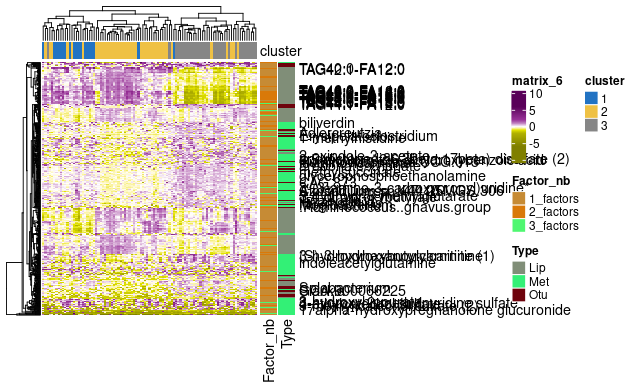

```r
draw(ht)
```

```r
write.xlsx(data_4, "processing/extracted_MOFA_features.xlsx")
```

```r
pdf("results/figures_2/heatmap_all_factors_model_4_spearman_distance.pdf")
data <- cbind(data_met, data_lip, data_mi)
data_2 <- data[,colnames(data) %in% c(rownames(lip_f1), rownames(met_f1), rownames(mic_f1),
                                      rownames(lip_f2), rownames(met_f2), rownames(mic_f2),
                                      rownames(lip_f3), rownames(met_f3), rownames(mic_f3),
                                      rownames(lip_f5), rownames(met_f5), rownames(mic_f5),
                                      rownames(lip_f8), rownames(met_f8), rownames(mic_f8)
                                      )]
data_2 <- data.frame(t(scale(t(data_2))))
data_2$X <- rownames(data_2)
data_2 <- merge(cluster, data_2, by = "X")
ht = Heatmap(data_2[,-c(1:2)], col = col_fun1, right_annotation = rowAnnotation(cluster = as.factor(data_2$cluster), col = list(cluster = c("1" = col[2],
                                                                                                                                            "2" = col[3],
                                                                                                                                            "3" = col[4]))), clustering_distance_rows = "spearman")
draw(ht)
dev.off()
```

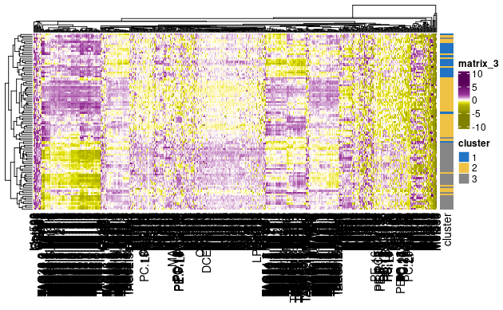

```r
draw(ht)
```

```r
clustering_distance_rows
```

```
Error: object 'clustering_distance_rows' not found
```

```r
list_lip <- list(f1 = rownames(lip_f1),
                 f2 = rownames(lip_f2))

library(ggvenn)
pdf("results/figures_2/overlap_F1_F2_lipids_model_4.pdf")
ggvenn(
  list_lip,
  fill_color = c("#0073C2FF", "#EFC000FF", "#868686FF", "#CD534CFF"),
  stroke_size = 0.5, set_name_size = 4
  )
dev.off()
```

```r
list_met <- list(f1 = rownames(met_f1),
                 f2 = rownames(met_f2))

library(ggvenn)
pdf("results/figures_2/overlap_F1_F2_F5_met_model_4.pdf")
ggvenn(
  list_met,
  fill_color = c("#0073C2FF", "#EFC000FF", "#868686FF", "#CD534CFF"),
  stroke_size = 0.5, set_name_size = 4
  )
dev.off()
```

```r
data_samples <- data.frame(samples = rownames(MOFAobject@expectations$Z$group1), F1 = MOFAobject@expectations$Z$group1[,1], F2 = MOFAobject@expectations$Z$group1[,2], F5 = MOFAobject@expectations$Z$group1[,5])
cluster <- data.frame(samples = MOFAobject@samples_metadata$sample, cluster = MOFAobject@samples_metadata$cluster)
data_samples <- merge(cluster, data_samples, by = "samples")
```

```r
length(rownames(lip_f1)[rownames(lip_f1) %in% rownames(lip_f2)])
length(rownames(met_f1)[rownames(met_f1) %in% rownames(met_f2)])
```

```r
library(tidyverse)
```

```r
col <- c("#2273C3","#EFC144","#868686")
```

```r
pdf("results/figures_2/plot_factor_F1_F2_mofa_model_4.pdf")
p <- plot_factors(MOFAobject, factors = c(1,2), color_by = "cluster")+stat_ellipse(aes(color= color_by), geom = "polygon", alpha = 0.25)+ scale_color_manual(values=col)+ scale_fill_manual(values=col)
p
dev.off()

pdf("results/figures_2/plot_factor_F5_F6_mofa_model_4.pdf")
p <- plot_factors(MOFAobject, factors = c(5,6), color_by = "cluster")+stat_ellipse(aes(color= color_by), geom = "polygon", alpha = 0.25)+ scale_color_manual(values=col)+ scale_fill_manual(values=col)
p
dev.off()
```

```r
ann_colors = list(
    cluster = c(C1 = col[1], C2 = col[2], C3 = col[3])
)
```

```r
pdf("results/figures_2/plot_factor_F1_violin.pdf")
plot_factor(MOFAobject, factor = 1, color_by = "cluster", add_violin = T, add_boxplot = T, dodge = T)+ scale_color_manual(values=col)+ scale_fill_manual(values=col)
dev.off()
pdf("results/figures_2/plot_factor_F2_violin.pdf")
plot_factor(MOFAobject, factor = 2, color_by = "cluster", add_violin = T, add_boxplot = T, dodge = T)+ scale_color_manual(values=col)+ scale_fill_manual(values=col)
dev.off()
plot_factor(MOFAobject, factor = 4, color_by = "cluster", add_violin = T, add_boxplot = T, dodge = T)
```

```r
pdf("results/figures_2/heatmap_clean_MOFA_F1_model_4_lipids.pdf")
plot_data_heatmap(MOFAobject, factor = 1, view = "Lipids", features = 72, denoise = TRUE, cluster_rows = T, cluster_cols = T, annotation_samples = "cluster", annotation_colors = ann_colors)
dev.off()

pdf("results/figures_2/heatmap_clean_MOFA_F1_model_4_metabolites.pdf")
plot_data_heatmap(MOFAobject, factor = 1, view = "Metabolites", features = 68, denoise = TRUE, cluster_rows = T, cluster_cols = T, annotation_samples = "cluster", annotation_colors = ann_colors)
dev.off()


pdf("results/figures_2/heatmap_clean_MOFA_F2_model_4_lipids.pdf")
plot_data_heatmap(MOFAobject, factor = 2, view = "Lipids", features = 72, denoise = TRUE, cluster_rows = T, cluster_cols = T, annotation_samples = "cluster", annotation_colors = ann_colors)
dev.off()

pdf("results/figures_2/heatmap_clean_MOFA_F2_model_4_metabolites.pdf")
plot_data_heatmap(MOFAobject, factor = 2, view = "Metabolites", features = 68, denoise = TRUE, cluster_rows = T, cluster_cols = T, annotation_samples = "cluster", annotation_colors = ann_colors)
dev.off()
```

```r
library(ggplot2)
ggplot(data_samples, aes(x = F1, y = F2, color = as.factor(cluster)))+geom_point()
```

```r
ggplot(data_samples, aes(x = 1, y = F1, fill = as.factor(cluster)))+geom_dotplot(binaxis = "y", stackdir = "center")
pdf("results/figures_2/distribution_samples_F1_model_4.pdf")
ggplot(data_samples, aes(x = 1, y = F1, fill = as.factor(cluster)))+geom_dotplot(binaxis = "y", stackdir = "center")+ scale_color_manual(values=col)+ scale_fill_manual(values=col)
dev.off()

ggplot(data_samples, aes(x = 1, y = F2, fill = as.factor(cluster)))+geom_dotplot(binaxis = "y", stackdir = "center")
pdf("results/figures_2/distribution_samples_F2_model_4.pdf")
ggplot(data_samples, aes(x = 1, y = F2, fill = as.factor(cluster)))+geom_dotplot(binaxis = "y", stackdir = "center")+ scale_color_manual(values=col)+ scale_fill_manual(values=col)
dev.off()

pdf("results/figures_2/distribution_samples_F5_model_4.pdf")
ggplot(data_samples, aes(x = 1, y = F5, fill = as.factor(cluster)))+geom_dotplot(binaxis = "y", stackdir = "center")+ scale_color_manual(values=col)+ scale_fill_manual(values=col)
dev.off()
```

```r
col_fun1 = colorRamp2(c(-6,-2,-1, 0,1,2,6), c("#7F7F00","#B2B200" ,"#E5E500","white","#BF7FBF","#993299","#590059"))
```

```r
pdf("results/figures_2/heatmap_F1_model_4.pdf")
data <- cbind(data_met, data_lip, data_mi)
data_2 <- data[,colnames(data) %in% c(rownames(lip_f1), rownames(met_f1), rownames(mic_f1))]
data_2 <- data.frame(t(scale(t(data_2))))
data_2$samples <- rownames(data_2)
data_2 <- merge(cluster, data_2, by = "samples")
ht = Heatmap(data_2[,-c(1:2)], col = col_fun1, right_annotation = rowAnnotation(cluster = as.factor(data_2$cluster)))
draw(ht)
dev.off()
draw(ht)
```

```r
pdf("results/figures_2/heatmap_F2_model_4.pdf")
data <- cbind(data_met, data_lip, data_mi)
data_2 <- data[,colnames(data) %in% c(rownames(lip_f2), rownames(met_f2), rownames(mic_f2))]
data_2 <- data.frame(t(scale(t(data_2))))
data_2$samples <- rownames(data_2)
data_2 <- merge(cluster, data_2, by = "samples")
ht = Heatmap(data_2[,-c(1:2)], col = col_fun1, right_annotation = rowAnnotation(cluster = as.factor(data_2$cluster)))
draw(ht)
dev.off()
draw(ht)
```

```r
pdf("results/figures_2/heatmap_F6_model_4.pdf")
data <- cbind(data_met, data_lip, data_mi)
data_2 <- data[,colnames(data) %in% c(rownames(lip_f6), rownames(met_f6), rownames(mic_f6))]
data_2 <- data.frame(t(scale(t(data_2))))
data_2$samples <- rownames(data_2)
data_2 <- merge(cluster, data_2, by = "samples")
ht = Heatmap(data_2[,-c(1:2)], col = col_fun1, right_annotation = rowAnnotation(cluster = as.factor(data_2$cluster)))
draw(ht)
dev.off()
draw(ht)
```

```r
pdf("results/figures_2/heatmap_F5_model_4.pdf")
data <- cbind(data_met, data_lip, data_mi)
data_2 <- data[,colnames(data) %in% c(rownames(lip_f5), rownames(met_f5), rownames(mic_f5))]
data_2 <- data.frame(t(scale(t(data_2))))
data_2$samples <- rownames(data_2)
data_2 <- merge(cluster, data_2, by = "samples")
ht = Heatmap(data_2[,-c(1:2)], col = col_fun1, right_annotation = rowAnnotation(cluster = as.factor(data_2$cluster)))
draw(ht)
dev.off()
draw(ht)
```

```r
pdf("results/figures_2/heatmap_F3_model_4.pdf")
data <- cbind(data_met, data_lip, data_mi)
data_2 <- data[,colnames(data) %in% c(rownames(lip_f3), rownames(met_f3), rownames(mic_f3))]
data_2 <- data.frame(t(scale(t(data_2))))
data_2$samples <- rownames(data_2)
data_2 <- merge(cluster, data_2, by = "samples")
ht = Heatmap(data_2[,-c(1:2)], col = col_fun1, right_annotation = rowAnnotation(cluster = as.factor(data_2$cluster)))
draw(ht)
dev.off()
draw(ht)
```

pdf(“results/figures_2/heatmap_F1_model_4.pdf”) data <- cbind(data_met, data_lip, data_mi) data_2 <- data[,colnames(data) %in% c(rownames(lip_f1), rownames(met_f2), rownames(mic_f1))] data_2$samples <- rownames(data_2) data_2 <- merge(cluster, data_2, by = "samples") ht = Heatmap(data_2[,-c(1:2)], col = col_fun1, right_annotation = rowAnnotation(cluster = as.factor(data_2$cluster))) draw(ht) dev.off() draw(ht)

pdf(“results/figures_2/heatmap_F2_model_4.pdf”) data <- cbind(data_met, data_lip, data_mi) data_2 <- data[,colnames(data) %in% c(rownames(lip_f2), rownames(met_f2))] data_2$samples <- rownames(data_2) data_2 <- merge(cluster, data_2, by = "samples") ht = Heatmap(data_2[,-c(1:2)], col = col_fun1, right_annotation = rowAnnotation(cluster = as.factor(data_2$cluster))) draw(ht) dev.off() draw(ht)

```r
plot_factor(MOFAobject,
  factors = 1,
  color_by = "Factor1"
)
```

```r
plot_weights(MOFAobject,
 view = "Microbiome",
 factor = 1,
 nfeatures = 10,     # Top number of features to highlight
 scale = F           # Scale weights from -1 to 1
)
pdf("results/figures/MOFA_weight_factor_1.pdf")
plot_weights(MOFAobject,
 view = "Lipids",
 factor = 1,
 nfeatures = 10,     # Top number of features to highlight
 scale = F           # Scale weights from -1 to 1
)
dev.off()
```

```r
pdf("results/figures/top_features_metabolites_F1_model_4.pdf")
plot_top_weights(MOFAobject,
 view = "Metabolites",
 factor = 1,
 nfeatures = 10,     # Top number of features to highlight
 scale = T           # Scale weights from -1 to 1
)
dev.off()
```

```r
pdf("results/figures/top_features_lipids_F1_model_4.pdf")
plot_top_weights(MOFAobject,
 view = "Lipids",
 factor = 1,
 nfeatures = 10,     # Top number of features to highlight
 scale = T           # Scale weights from -1 to 1
)
dev.off()
```

```r
plot_factor(MOFAobject,
  factors = 1,
  color_by = "cluster",
  add_violin = TRUE,
  dodge = TRUE
)
```

```r
plot_factor(MOFAobject,
  factors = 1,
  color_by = "METS",
  dodge = TRUE,
  add_violin = TRUE
)
```

```r
plot_data_scatter(MOFAobject,
  view = "Lipids",
  factor = 1,
  features = 4,
  sign = "negative",
  color_by = "cluster")
pdf("results/figures/top_4_features_factor_1.pdf")
plot_data_scatter(MOFAobject,
  view = "Lipids",
  factor = 1,
  features = 4,
  sign = "negative",
  color_by = "group")
dev.off()
```

```r
plot_data_scatter(MOFAobject,
  view = "Metabolites",
  factor = 1,
  features = 4,
  sign = "negative",
  color_by = "cluster")
pdf("results/figures/top_4_features_metabolites_factor_1.pdf")
plot_data_scatter(MOFAobject,
  view = "Metabolites",
  factor = 1,
  features = 4,
  sign = "negative",
  color_by = "group")
dev.off()
```

```r
write.csv(rownames(lip_f1), "results/MOFA/list_model_4_lipids_F1.csv")
write.csv(rownames(met_f1), "results/MOFA/list_model_4_metabolites_F1.csv")

write.csv(rownames(lip_f2), "results/MOFA/list_model_4_lipids_F2.csv")
write.csv(rownames(met_f2), "results/MOFA/list_model_4_metabolites_F2.csv")
```

```r
plot_data_heatmap(MOFAobject,
  view = "Lipids",
  factor = 1,
  features = 500,
  cluster_rows = FALSE, cluster_cols = FALSE,
  show_rownames = TRUE, show_colnames = FALSE,
  scale = "row",
  denoise = TRUE
)
```

Question –> number of groups ? Right now only one –> should change model_opts$ard_factors <- TRUE (if multiple groups)